# Final Project–Classification

Xin Wang

December 7, 2016

Step 1-2: In regression problem set

In this classification problem set, the process focus on predicting whether the student fail or pass the G3 exam according to the predictors.

### Step 3: Obtain and read in data

### Step 4: Clean the data. Use the proper delimit, dealing with the missing data, treat the incorrect data class/type

```r
# Set working directory
setwd("C:/Users/admin/Downloads/R projects/Final Project")
require(readr)
require(ISLR)
```

```r
require(ggplot2)
require(GGally)
require(caret)
require(MASS)
require(klaR)
require(mda)
require(glmnet)
require(class)
require(randomForest)
require(rpart)
require(gbm)
```

Read in data

```r
LangData <- read_delim("sp.csv", delim = ";")
# test if has missing data
table(is.na(LangData))
```

```
##
## FALSE
## 21417
```

```r
# no missing value
LangData <- as.data.frame(LangData)
```

### Step 5: Get to know your data with summarize and visualization tools

```r
summary(LangData)
```

```
##     school              sex                 age          address
##  Length:649         Length:649         Min.   :15.00   Length:649
##  Class :character   Class :character   1st Qu.:16.00   Class :character
##  Mode  :character   Mode  :character   Median :17.00   Mode  :character
##                                        Mean   :16.74
##                                        3rd Qu.:18.00
##                                        Max.   :22.00
##    famsize            Pstatus               Medu            Fedu
##  Length:649         Length:649         Min.   :0.000   Min.   :0.000
##  Class :character   Class :character   1st Qu.:2.000   1st Qu.:1.000
##  Mode  :character   Mode  :character   Median :2.000   Median :2.000
##                                        Mean   :2.515   Mean   :2.307
##                                        3rd Qu.:4.000   3rd Qu.:3.000
##                                        Max.   :4.000   Max.   :4.000
##      Mjob               Fjob              reason
##  Length:649         Length:649         Length:649
##  Class :character   Class :character   Class :character
##  Mode  :character   Mode  :character   Mode  :character
##
##
##
##    guardian           traveltime      studytime        failures
##  Length:649         Min.   :1.000   Min.   :1.000   Min.   :0.0000
##  Class :character   1st Qu.:1.000   1st Qu.:1.000   1st Qu.:0.0000
##  Mode  :character   Median :1.000   Median :2.000   Median :0.0000
##                     Mean   :1.569   Mean   :1.931   Mean   :0.2219
##                     3rd Qu.:2.000   3rd Qu.:2.000   3rd Qu.:0.0000
##                     Max.   :4.000   Max.   :4.000   Max.   :3.0000
##   schoolsup            famsup              paid
##  Length:649         Length:649         Length:649
##  Class :character   Class :character   Class :character
##  Mode  :character   Mode  :character   Mode  :character
##
##
##
##   activities          nursery             higher
##  Length:649         Length:649         Length:649
##  Class :character   Class :character   Class :character
##  Mode  :character   Mode  :character   Mode  :character
##
```

[output cut: 8 more lines]

```
##                                        Max.   :5.000   Max.   :5.00
##      goout            Dalc            Walc          health
##  Min.   :1.000   Min.   :1.000   Min.   :1.00   Min.   :1.000
##  1st Qu.:2.000   1st Qu.:1.000   1st Qu.:1.00   1st Qu.:2.000
##  Median :3.000   Median :1.000   Median :2.00   Median :4.000
##  Mean   :3.185   Mean   :1.502   Mean   :2.28   Mean   :3.536
##  3rd Qu.:4.000   3rd Qu.:2.000   3rd Qu.:3.00   3rd Qu.:5.000
##  Max.   :5.000   Max.   :5.000   Max.   :5.00   Max.   :5.000
##     absences            G1             G2              G3
##  Min.   : 0.000   Min.   : 0.0   Min.   : 0.00   Min.   : 0.00
##  1st Qu.: 0.000   1st Qu.:10.0   1st Qu.:10.00   1st Qu.:10.00
##  Median : 2.000   Median :11.0   Median :11.00   Median :12.00
##  Mean   : 3.659   Mean   :11.4   Mean   :11.57   Mean   :11.91
##  3rd Qu.: 6.000   3rd Qu.:13.0   3rd Qu.:13.00   3rd Qu.:14.00
##  Max.   :32.000   Max.   :19.0   Max.   :19.00   Max.   :19.00
```

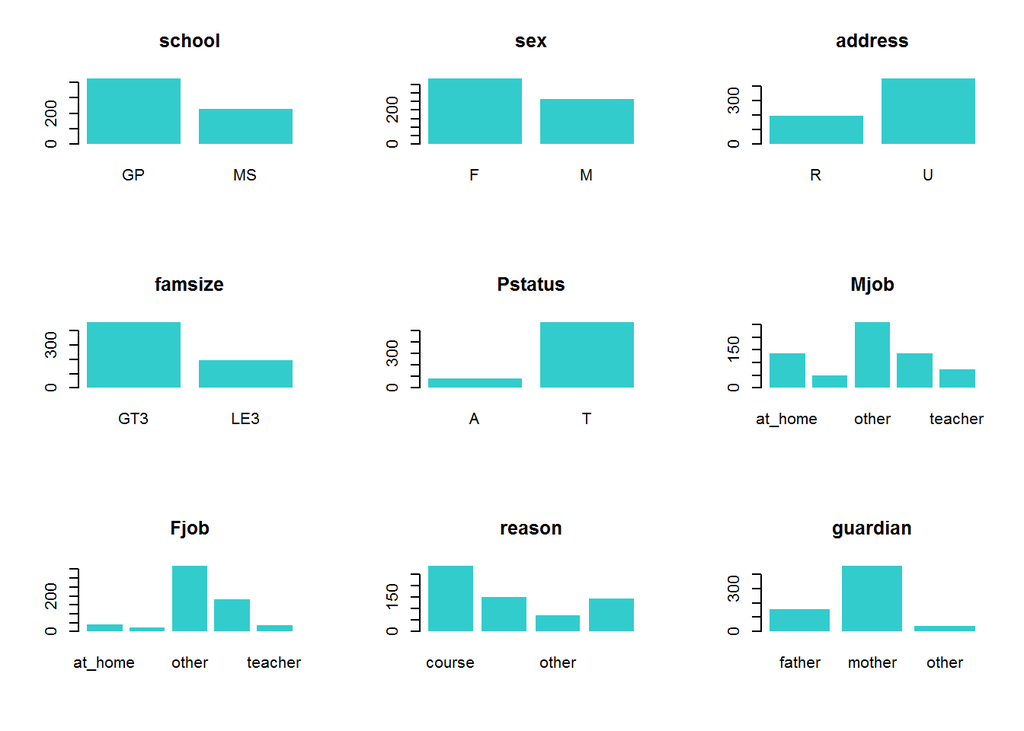

```r
charName <- names(LangData) %in% c("school", "sex", "address", "famsize", "Pstatus", "Mjob", "Fjob", "reason", "guardian", "schoolsup", "famsup", "paid", "activities", "nursery", "higher", "internet", "romantic")
charData <- LangData[charName]
numData <- LangData[!charName]

# plots for Character Variables
mainnames <- names(charData)
par(mfrow=c(3, 3))
for (i in 1:9){
    barplot(table(charData[,i]), main=mainnames[i], col = "#33cccc", border = NA)
}
```